# IEAP Python Series 03

Group Assignment

Authors

Jennifer Houmard

Ayesha Waheed

Werner Binche

```python
# Import libraries used throughout the assignment
import numpy as np
import matplotlib.pyplot as plt
from scipy.signal import butter, filtfilt
```

# 1 1. Group workflow and division of tasks between group members

## 1.1 GitHub repository

The group assignment was developed in Python using Visual Studio Code (VS Code) and managed through a public GitHub repository:

https://github.com/jenniferhoumard/IEAP-Python-Series03-Group

To organize the group work, one member initially created the GitHub repository, added the other members as collaborators, and prepared the master Quarto document and separate subsection files (.qmd). The headings and subsections were predefined according to the assignment requirements so that each member had a clear structure to follow and knew exactly where to add their work. This also allowed members to work on their assigned files independently, reducing overlap and potential conflicts.

The assignment was developed in Python using Visual Studio Code (VS Code). Quarto (.qmd) files were used to combine Python code, explanations, tables, and plots in the same document. The master Quarto file brings together all the subsections into a single report with consistent headings, automatic numbering, and a table of contents.

## 1.2 Division of tasks

The assignment was divided among the three group members, with each student responsible for specific sections and their corresponding Quarto files.

| Section | Quarto file |
| --- | --- |
| 01 | `01_groups.qmd` |
| 02 | `02_1_zero_crossings.qmd` |
| 02 | `02_2_explain_improve_code.qmd` |
| 02 | `02_3_local_maxima_minima.qmd` |
| 03 | `03_1_create_signal.qmd` |
| 03 | `03_2_remarkable_points.qmd` |
| 03 | `03_3_signal_frequency.qmd` |
| 04 | `04_1_noisy_signal.qmd` |
| 04 | `04_2_noisy_remarkable_points.qmd` |
| 04 | `04_3_low_pass_filter.qmd` |
| 05 | `05_critical_point.qmd` |

Although each section was assigned to a specific student, Sections 1 and 5 were completed collaboratively.

For Section 1 (Group workflow and division of tasks), all three members discussed and agreed on the organization of the assignment, the division of responsibilities, and the branching strategy. One student was responsible for documenting these decisions in Quarto.

For Section 5 (Critical points and problem solving), the group collectively identified and discussed the three most critical problems encountered during the assignment. All members contributed to brainstorming possible solutions and agreed on the final answers, which were then documented by the assigned student.

The responsibilities were allocated as follows:

| Team member | Assigned sections |
| --- | --- |
| **Werner Binche** | 02, 05 |
| **Ayeesha Waheed** | 03 |
| **Jennifer Houmard** | 01, 04 |

## 1.3 Branching strategy

We adopted a feature-branch workflow, creating one branch for each of the five main sections of the assignment:

1. Group workflow and division of tasks between group members
2. Create functions to find and plot remarkable points
3. Analyze a known signal
4. Redo the analysis with a noisy signal
5. Critical points and problem solving

Each branch is dedicated to its corresponding section, allowing group members to work independently without modifying the same files.

All branches originate from the main branch. Once a section is completed, the responsible student commits and pushes their changes to GitHub, then creates a pull request for review before merging into main.

As the technical sections are dependent on one another, Sections 2, 3, and 4 are integrated in sequence to ensure that the functions and variables required by later sections are available. The documentation sections can be developed separately.

This approach keeps the main branch as the integrated version of the assignment while maintaining a clear commit history and individual contributions.

# 2 2. Create functions to find and plot remarkable points

## 2.1 Functions to find zero crossings and to plot them

**Objective:** Create functions to detect positive and negative zero crossings in a signal and plot their positions.

### 2.1.1 Create the signal and index arrays

We use the signal and index arrays provided in the exercises.

```python
index =  [    0,    1,    2,    3,    4,    5,    6,    7,    8,    9   ]
signal =  [   -1,    1,    2,    1,    0,   -1,    1,    2,    1,   -2   ]
```

```
Type of index: <class 'numpy.ndarray'>
Type of signal: <class 'numpy.ndarray'>
Index: [0 1 2 3 4 5 6 7 8 9]
Signal: [-1  1  2  1  0 -1  1  2  1 -2]
```

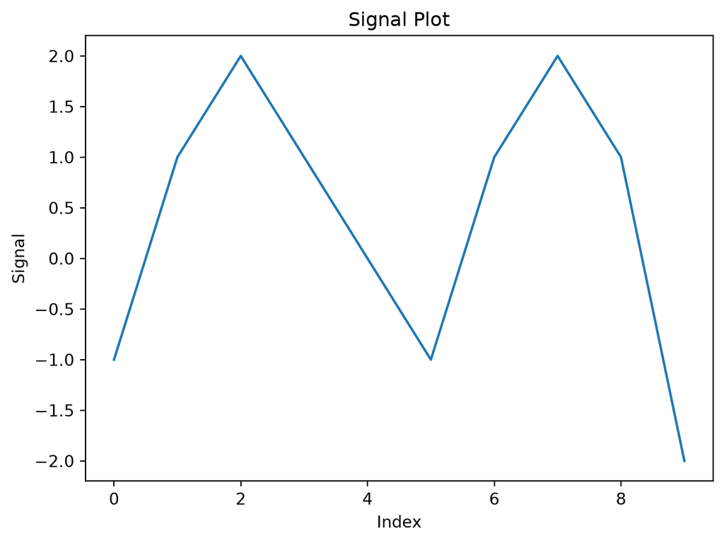

```python
index = np.array(index)
signal = np.array(signal)

print("Type of index:", type(index))
print("Type of signal:", type(signal))
print("Index:", index)
print("Signal:", signal)

# plot the signal

plt.plot(index, signal)
plt.xlabel("Index")
plt.ylabel("Signal")
plt.title("Signal Plot")
plt.show()
```

### 2.1.2 Find zero crossing points

A zero crossing occurs when the signal changes sign.

- **Positive crossing:** Negative to positive.
- **Negative crossing:** Positive to negative.

To identify these changes, we use `np.sign()`, `np.diff()`, and `np.where()`.

**1. Identify the signs of the signal**

First, `np.sign()` converts each signal value into:

- `-1`: Negative value
- `0`: Zero
- `1`: Positive value

**2. Detect changes between neighboring signs**

Next, `np.diff()` subtracts each sign from the following sign to identify where the sign changes.

- **Positive difference:** A change toward a more positive sign.
- **Negative difference:** A change toward a more negative sign.
- **Zero difference:** No change in sign.

**3. Identify positive and negative changes**

We can separate the changes according to their direction.

```python
# Signal signs, differences, and indices of sign changes

signal_sign = np.sign(signal)
diff_signal_sign = np.diff(signal_sign)
where_diff_signal_sign_nonzero = np.where(diff_signal_sign != 0)[0]

print("Signal signs:", signal_sign)
print("Difference of signal signs:", diff_signal_sign)
print("Indices where the difference of signal signs is non-zero:", where_diff_signal_sign_nonzero)
```

```
Signal signs: [-1  1  1  1  0 -1  1  1  1 -1]
Difference of signal signs: [ 2  0  0 -1 -1  2  0  0 -2]
Indices where the difference of signal signs is non-zero: [0 3 4 5 8]
```

**4. Alternative method**

The same sign-change indices can be obtained in a single line:

```python
# Alternative method to find zero crossing points
zero_crossings = np.where(np.diff(np.sign(signal)))[0]
print("Zero crossing points (indices):", zero_crossings)
```

```
Zero crossing points (indices): [0 3 4 5 8]
```

### 2.1.3 Find positive zero-crossing functions

```python
# Find positive zero-crossing points
positive_zero_crossing = np.where(diff_signal_sign > 0)[0]
print("Positive zero crossing points (indices):", positive_zero_crossing)
```

```
Positive zero crossing points (indices): [0 5]
```

### 2.1.4 Find negative zero-crossing points

```python
negative_zero_crossing = np.where(diff_signal_sign < 0)[0]
print("Negative zero crossing points (indices):", negative_zero_crossing)
```

```
Negative zero crossing points (indices): [3 4 8]
```

### 2.1.5 d) Plot the signal with positive and negative zero-crossings

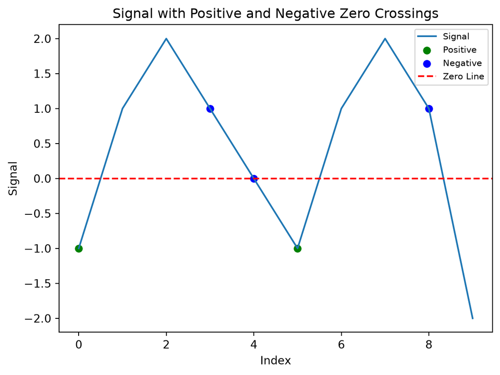

```python
plt.plot(index, signal, label='Signal')
plt.scatter(index[positive_zero_crossing], signal[positive_zero_crossing], color='green', label='Positive')
plt.scatter(index[negative_zero_crossing], signal[negative_zero_crossing], color='blue', label='Negative')
plt.axhline(y=0, color='red', linestyle='--', label='Zero Line')
plt.xlabel("Index")
plt.ylabel("Signal")
plt.title("Signal with Positive and Negative Zero Crossings")
plt.legend(fontsize=8)
plt.show()
```

### 2.1.6 Define reusable zero-crossing functions

We define three functions to detect positive and negative zero crossings, including cases where the signal contains exact zero values.

**1. Detect crossings without zero values***

The function `find_zero_crossings_no_zeros()` compares neighboring signs and returns the indices where the signal changes from negative to positive or from positive to negative.

```python
def find_zero_crossings_no_zeros(signs: np.ndarray):
    """Return indices where a zero-free sign array changes direction.

    Parameters
    ----------
    signs : np.ndarray
        One-dimensional array of negative and positive signs, with no zeros.

    Returns
    -------
    tuple[np.ndarray, np.ndarray]
        Indices of negative-to-positive changes, then positive-to-negative
        changes. Each result is an integer array.
    """
    # Compare neighboring signs; the direction of each difference identifies
    # the direction of a crossing.
    diff = np.diff(signs)
    # A positive difference is a negative-to-positive change; a negative one
    # is a positive-to-negative change.
    i_cross_pos = np.where(diff > 0)[0]
    i_cross_neg = np.where(diff < 0)[0]
    return i_cross_pos, i_cross_neg
```

**2. Handle zero values**

The function `propagate_signs_over_zeros()` replaces exact zero values with the preceding nonzero sign.

```python
def propagate_signs_over_zeros(signs: np.ndarray):
    """Replace zero signs using the nearest preceding nonzero sign.

    Interior and trailing zeros inherit the preceding sign. Leading zeros
    inherit the first nonzero sign; an all-zero array remains unchanged.

    Parameters
    ----------
    signs : np.ndarray
        One-dimensional array containing negative, zero, or positive signs.

    Returns
    -------
    np.ndarray
        A copy of ``signs`` with zeros filled according to these rules.
    """
    # Work on a copy so filling zeros does not modify the caller's array.
    signs_no_zeros = signs.copy()
    # There are no values to fill or inspect in an empty array.
    if signs_no_zeros.size == 0:
        return signs_no_zeros

    # Map each nonzero value to its own index; zeros start with index 0 as a
    # placeholder. The cumulative maximum carries the last nonzero index
    # forward, so interior and trailing zeros inherit the preceding sign.
    mask = signs_no_zeros != 0
    idx = np.where(mask, np.arange(len(signs_no_zeros)), 0)
    idx = np.maximum.accumulate(idx)
    signs_no_zeros = signs_no_zeros[idx]

    # The cumulative pass maps leading zeros to index 0. Replace them with the
    # first nonzero sign instead; if none exists, the all-zero array stays as-is.
    if signs_no_zeros[0] == 0:
        i_first_nonzero = np.where(signs != 0)[0]
        if len(i_first_nonzero) > 0:
            signs_no_zeros[: i_first_nonzero[0]] = signs[i_first_nonzero[0]]

    return signs_no_zeros
```

**3. Combine the functions**

The function `find_zero_crossings()` combines the previous two functions. It first checks the input, handles zero values if needed, and then identifies positive and negative crossings.

```python
def find_zero_crossings(s: np.ndarray):
    """Find positive and negative crossings in a one-dimensional signal.

    Zero-valued samples are assigned the preceding nonzero sign; leading
    zeros use the first nonzero sign. An all-zero signal has no crossings.

    Parameters
    ----------
    s : np.ndarray
        One-dimensional array of signal samples.

    Returns
    -------
    tuple[np.ndarray, np.ndarray]
        Indices of negative-to-positive crossings, then positive-to-negative
        crossings. The index marks the sample immediately before the change.

    Raises
    ------
    ValueError
        If ``s`` is not one-dimensional.
    """

    # Normalize array-like input, then reject signals with more than one dimension.
    s = np.asarray(s)
    if s.ndim != 1:
        raise ValueError("Input must be a 1D array")

    # Reduce each sample to an integer sign: negative, zero, or positive.
    signs = np.sign(s).astype(int)
    # Locate zeros so propagation can be skipped when every sign is nonzero.
    i_zeros = np.where(signs == 0)[0]
    if i_zeros.size > 0:
        # Fill zero signs before comparing adjacent samples for crossings.
        signs_no_zeros = propagate_signs_over_zeros(signs)
    else:
        signs_no_zeros = signs

    return find_zero_crossings_no_zeros(signs_no_zeros)
```

### 2.1.7 Test the zero-crossing functions

To verify that our functions work correctly, we use `test_find_zero_crossings()`.

The tests check different situations, including positive and negative crossings, exact zero values, signals without crossings, empty arrays, and invalid inputs.

```python
def test_find_zero_crossings():
    """Check crossing results for normal, boundary, and invalid inputs.

    These assertions cover representative behavior; they are not an exhaustive
    test of every possible signal value.

    Returns
    -------
    None
        Returns normally when all assertions pass; otherwise raises
        ``AssertionError``.
    """
    # Alternating signs exercise both crossing directions multiple times.
    s = np.array([-1, 1, -1, 1, -1])
    i_pos, i_neg = find_zero_crossings(s)
    assert np.array_equal(i_pos, np.array([0, 2]))
    assert np.array_equal(i_neg, np.array([1, 3]))

    # A single transition in either direction returns only that direction's index.
    i_pos, i_neg = find_zero_crossings([-1, 2, 3])
    assert np.array_equal(i_pos, np.array([0]))
    assert np.array_equal(i_neg, np.array([]))
    i_pos, i_neg = find_zero_crossings([1, -2, -3])
    assert np.array_equal(i_pos, np.array([]))
    assert np.array_equal(i_neg, np.array([0]))

    # Interior zeros inherit the preceding sign when determining crossings.
    s = np.array([-1, 0, 0, 1, 0, -1])
    i_pos, i_neg = find_zero_crossings(s)
    assert np.array_equal(i_pos, np.array([2]))
    assert np.array_equal(i_neg, np.array([4]))

    # Leading zeros adopt the first nonzero sign; the remaining change is negative.
    s = np.array([0, 0, 1, 0, -1, 0])
    i_pos, i_neg = find_zero_crossings(s)
    assert np.array_equal(i_pos, np.array([]))
    assert np.array_equal(i_neg, np.array([3]))

    # Signals with no sign change, including all-zero and all-negative inputs.
    for s in (np.array([0, 0, 0]), np.array([-1, -2, -3])):
        i_pos, i_neg = find_zero_crossings(s)
        assert np.array_equal(i_pos, np.array([]))
        assert np.array_equal(i_neg, np.array([]))

    # Empty and single-sample signals cannot contain a crossing.
    for s in (np.array([], dtype=int), np.array([-1]), np.array([0]), np.array([1])):
        i_pos, i_neg = find_zero_crossings(s)
        assert np.array_equal(i_pos, np.array([]))
        assert np.array_equal(i_neg, np.array([]))

    # The zero-propagation helper also accepts an empty array and does not mutate input.
    empty_signs = np.array([], dtype=int)
    assert np.array_equal(propagate_signs_over_zeros(empty_signs), empty_signs)
    signs = np.array([0, -1, 0, 1, 0])
    original_signs = signs.copy()
    assert np.array_equal(
        propagate_signs_over_zeros(signs), np.array([-1, -1, -1, 1, 1])
    )
    assert np.array_equal(signs, original_signs)

    # Multidimensional input is rejected with the documented exception.
    try:
        find_zero_crossings(np.array([[1, -1], [-1, 1]]))
    except ValueError:
        pass
    else:
        raise AssertionError("Expected ValueError for a multidimensional signal")


# Run the assertions when this cell is executed.
try:
    test_find_zero_crossings()
    print("All tests passed.")
except AssertionError:
    raise
```

```
All tests passed.
```

### 2.1.8 Define plotting functions

We define the following functions to visualize the signal and its positive and negative zero crossings.

**1. Plot the signal**

The `plot_signal()` function plots the signal against its index or time values and adds a horizontal reference line at zero.

```python
def plot_signal(i: np.ndarray, s: np.ndarray, color: str = "blue"):
    """Draw a signal and a horizontal zero line on the current axes.

    Parameters
    ----------
    i : np.ndarray
        Coordinates for the signal samples, typically sample indices or times.
    s : np.ndarray
        Signal values corresponding to ``i``.
    color : str, optional
        Line and marker color for the signal; defaults to ``"blue"``.

    Returns
    -------
    None
        Adds the signal and zero line to the current Matplotlib axes.
    """
    plt.axhline(y=0, color="gray", linestyle="-")  # before to be under the signal
    plt.plot(i, s, ".-", markersize=5, linewidth=0.25, color=color, label="signal")
    plt.ylabel("signal")
    plt.xlabel("index")
```

**2. Plot remarkable points**

The `plot_remarkable_points()` function is used to mark specific points on the signal using different colors, symbols, and labels.

```python
def plot_remarkable_points(t: np.ndarray, s: np.ndarray, format: str, label: str):
    """Draw labeled signal points on the current axes.

    Parameters
    ----------
    t : np.ndarray
        Horizontal coordinates of the points.
    s : np.ndarray
        Vertical coordinates of the points, corresponding to ``t``.
    format : str
        Matplotlib format string specifying marker and color.
    label : str
        Legend label for the plotted points.

    Returns
    -------
    None
        Adds the points to the current Matplotlib axes.
    """
    plt.plot(t, s, format, markersize=10, label=label)
```

**3.Plot positive zero crossings**

The `plot_positive_zero_crossings()` function uses `find_zero_crossings()` to identify where the signal changes from negative to positive and marks these points with red upward triangles.

```python
def plot_positive_zero_crossings(i: np.ndarray, s: np.ndarray):
    """Mark negative-to-positive crossings on the current axes.

    Parameters
    ----------
    i : np.ndarray
        Coordinates corresponding to the signal samples.
    s : np.ndarray
        One-dimensional signal used to locate the crossings; its length must
        match ``i``.

    Returns
    -------
    None
        Adds the crossing markers to the current Matplotlib axes.
    """
    i_pos, _ = find_zero_crossings(s)
    plot_remarkable_points(i[i_pos], s[i_pos], "^r", "positive zero crossings")
```

**4. Plot negative zero crossings**

The `plot_negative_zero_crossings()` function identifies where the signal changes from positive to negative and marks these points with yellow downward triangles.

```python
def plot_negative_zero_crossings(i: np.ndarray, s: np.ndarray):
    """Mark positive-to-negative crossings on the current axes.

    Parameters
    ----------
    i : np.ndarray
        Coordinates corresponding to the signal samples.
    s : np.ndarray
        One-dimensional signal used to locate the crossings; its length must
        match ``i``.

    Returns
    -------
    None
        Adds the crossing markers to the current Matplotlib axes.
    """
    _, i_neg = find_zero_crossings(s)
    plot_remarkable_points(i[i_neg], s[i_neg], "vy", "negative zero crossings")
```

**5. Plot both zero-crossing directions**

The `plot_zero_crossings()` function combines the previous two functions to mark both positive and negative zero crossings on the same graph.

```python
def plot_zero_crossings(i: np.ndarray, s: np.ndarray):
    """Mark both crossing directions on the current axes.

    Parameters
    ----------
    i : np.ndarray
        Coordinates corresponding to the signal samples.
    s : np.ndarray
        One-dimensional signal used to locate the crossings; its length must
        match ``i``.

    Returns
    -------
    None
        Adds positive- and negative-crossing markers to the current axes.
    """
    plot_positive_zero_crossings(i, s)
    plot_negative_zero_crossings(i, s)
```

### 2.1.9 Display the final result

Finally, `display_signal_and_crossings()` combines the signal plot with the positive and negative zero-crossing markers. It also adds a legend and grid to make the graph easier to read.

```python
def display_signal_and_crossings(i: np.ndarray, s: np.ndarray):
    """Display a signal with both crossing directions, legend, and grid.

    Parameters
    ----------
    i : np.ndarray
        Coordinates corresponding to the signal samples.
    s : np.ndarray
        One-dimensional signal used to locate the crossings; its length must
        match ``i``.

    Returns
    -------
    None
        Creates and displays a Matplotlib figure containing the signal and
        its positive and negative zero-crossing markers.
    """
    plt.figure()
    plot_signal(i, s)
    plot_positive_zero_crossings(i, s)
    plot_negative_zero_crossings(i, s)
    plt.legend(bbox_to_anchor=(1.05, 1), loc="upper left")
    plt.grid(True)
    plt.show()
```

### 2.1.10 Example using the original signal

We apply the function to the example signal defined at the beginning of this section.

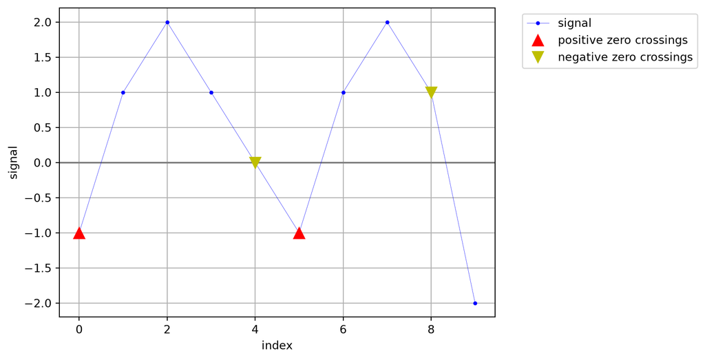

```python
# Example usage
display_signal_and_crossings(index, signal)
```

## 2.2 Explain and improve the previous code

- We’ve improved the previous code by adding some line to explain each commands. We made several changes to the original code to make it more readable and easier to understand.
- We reorganized the different parts of the code into clear functions, added comments and explanations for the main steps, and used more explicit variable and function names.
- We also added tests to check that the zero-crossing detection works correctly for different types of signals, including signals containing zeros.
- Finally, we improved the visualization by separating the plotting functions and clearly displaying positive and negative zero crossings.

## 2.3 What is the role of units tests provided for find_zero_crossings ?

- The unit tests provided for “find_zero_crossings” are used to check that the function works correctly for different types of input signals.
- They verify that the function correctly detects the zero-crossing points and gives the expected results. They also help detect errors in the implementation and ensure that changes to the function do not break its expected behaviour.
- Therefore, the unit tests are used to ‘validate the correctness and reliability of “find_zero_crossings”’.

## 2.4 Create new functions to find the local maxima and minima

**Objective:** Define functions to detect and plot local maxima and minima in a signal.

### 2.4.1 Find local maxima and minima

Local maxima are points where the signal changes from increasing to decreasing, while local minima occur when it changes from decreasing to increasing.

The `find_local_maxima_minima()` function uses `np.diff()` to calculate the differences between neighboring samples and `find_zero_crossings()` to identify these changes.

```python
def find_local_maxima_minima(s: np.ndarray):
    """Return indices of local maxima and minima in a one-dimensional signal.

    Extrema are found where the sign of the first difference changes:
    positive-to-negative for maxima and negative-to-positive for minima.
    For flat extrema, the zero-crossing policy selects the plateau's last
    sample. Endpoints are not considered extrema.

    Parameters
    ----------
    s : np.ndarray
        One-dimensional array of signal samples.

    Returns
    -------
    tuple[np.ndarray, np.ndarray]
        Indices of local maxima, then local minima.
    """
    # Differences represent the signal's change from one sample to the next.
    ds = np.diff(s)

    # The crossing helper returns negative-to-positive first (minima of ds),
    # followed by positive-to-negative (maxima of ds).
    i_min, i_max = find_zero_crossings(ds)

    # A change between difference entries occurs at the intervening signal sample.
    i_max = i_max + 1
    i_min = i_min + 1

    return i_max, i_min
```

### 2.4.2 Define plotting functions

We create three functions to visualize the detected maxima and minima.

**1. Plot local maxima**

The `plot_local_maxima()` function identifies local maxima and marks them with red circles.

```python
def plot_local_maxima(i: np.ndarray, s: np.ndarray):
    """Plot local maxima using orange circle markers.

    Parameters
    ----------
    i : np.ndarray
        Coordinates corresponding to the samples in ``s``.
    s : np.ndarray
        One-dimensional signal.

    Returns
    -------
    None
        Adds the local maxima to the current Matplotlib axes.
    """
    i_max, _ = find_local_maxima_minima(s)
    plot_remarkable_points(i[i_max], s[i_max], "or", "local maxima")
```

**2. Plot local minima**

The `plot_local_minima()` function identifies local minima and marks them with blue circles.

```python
def plot_local_minima(i: np.ndarray, s: np.ndarray):
    """Plot local minima using blue circle markers.

    Parameters
    ----------
    i : np.ndarray
        Coordinates corresponding to the samples in ``s``.
    s : np.ndarray
        One-dimensional signal.

    Returns
    -------
    None
        Adds the local minima to the current Matplotlib axes.
    """
    _, i_min = find_local_maxima_minima(s)
    plot_remarkable_points(i[i_min], s[i_min], "ob", "local minima")
```

**3. Plot both maxima and minima**

The `plot_maxima_minima()` function combines the previous two functions to display both types of points on the same graph.

```python
def plot_maxima_minima(i: np.ndarray, s: np.ndarray):
    """Plot both local maxima and minima on the current axes.

    Parameters
    ----------
    i : np.ndarray
        Coordinates corresponding to the samples in ``s``.
    s : np.ndarray
        One-dimensional signal.

    Returns
    -------
    None
        Adds maxima and minima markers to the current Matplotlib axes.
    """
    plot_local_maxima(i, s)
    plot_local_minima(i, s)
```

### 2.4.3 Test the functions

To verify that `find_local_maxima_minima()` works correctly, we test it using the example signal, short signals, monotonic signals, and a signal containing a flat peak.

```python
def test_find_local_maxima_minima():
    """Check extrema indices for the example signal and simple edge cases."""
    # The example has peaks at indices 2 and 7, and a valley at index 5.
    i_max, i_min = find_local_maxima_minima(signal)
    assert np.array_equal(i_max, np.array([2, 7]))
    assert np.array_equal(i_min, np.array([5]))

    # Short and monotonic signals contain no interior extrema.
    for samples in (np.array([], dtype=int), np.array([1]), np.array([1, 2]), np.array([1, 2, 3])):
        i_max, i_min = find_local_maxima_minima(samples)
        assert np.array_equal(i_max, np.array([], dtype=int))
        assert np.array_equal(i_min, np.array([], dtype=int))

    # A flat peak is represented by its last sample under zero propagation.
    i_max, i_min = find_local_maxima_minima(np.array([0, 1, 2, 2, 1]))
    assert np.array_equal(i_max, np.array([3]))
    assert np.array_equal(i_min, np.array([], dtype=int))
```

**Run the tests**

We execute the test function to check that all assertions pass.

```python
test_find_local_maxima_minima()
print("Local maxima/minima tests passed.")
```

```
Local maxima/minima tests passed.
```

### 2.4.4 Display the final result

Finally, we use the plotting functions to display the original signal with its local maxima and minima.

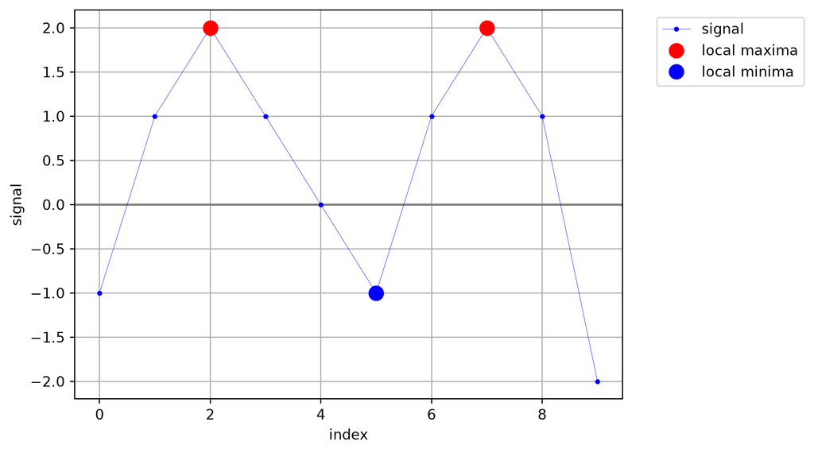

```python
# Display the signal with maxima and minima.
plt.figure()
plot_signal(index, signal)
plot_maxima_minima(index, signal)
plt.legend(bbox_to_anchor=(1.05, 1), loc="upper left")
plt.grid(True)
plt.show()
```

# 3 3. Analyze a known signal

## 3.1 Create the signal and plot it

### 3.1.1 Task

The task is to write functions that generate the signal **s** from the figure. It looks like a combination of two sine waves, so:

$$s(t) = s_1(t) + s_2(t)$$

I will build it step by step and plot after every step:

1. Make the time axis
2. Make and plot `s1`
3. Make and plot `s2`
4. Add them to get `s` and plot it
5. Plot all three together

### 3.1.2 Imports

```python
# numpy is used for the math (sine function and arrays of numbers)
import numpy as np

# matplotlib is used to draw the plots
import matplotlib.pyplot as plt
```

### 3.1.3 Plotting helper functions

Before creating the signal, I write two small functions for plotting. They are used in this file, and I can also reuse them in later exercises.

```python
def plot_signal(i, s, color="blue", label="signal", xlabel="index"):
    """Draw a signal and a horizontal zero line on the current axes."""
    # draw the zero line first, so it stays under the signal
    plt.axhline(y=0, color="gray", linestyle="-")

    # draw the signal with a small dot on every sample and a thin line
    plt.plot(i, s, ".-", markersize=5, linewidth=0.25, color=color, label=label)

    # axis labels
    plt.ylabel("signal")
    plt.xlabel(xlabel)


def plot_remarkable_points(t, s, format, label):
    """Draw labeled points (for example peaks) on the current axes."""
    # format is a matplotlib string like "*r" (red star) or "^g" (green triangle)
    # the markers are big, so they are easy to see on top of the signal
    plt.plot(t, s, format, markersize=10, label=label)
```

### 3.1.4 Step 1: Time axis

The signal runs from 0 to 2 seconds. I use a step of 0.01 s, which gives 200 points.

```python
def make_time(duration=2.0, step=0.01):
    """Return time values from 0 up to (not including) `duration`."""
    # np.arange makes a list of numbers: 0, 0.01, 0.02, ... up to just below 2.0
    return np.arange(0, duration, step)

# call the function to create our time axis
t = make_time()

# quick check that the time axis looks right
print("Number of points:", len(t))    # should be 200
print("First 5 values:", t[:5])       # should start at 0 and go up by 0.01
```

```
Number of points: 200
First 5 values: [0.   0.01 0.02 0.03 0.04]
```

### 3.1.5 Step 2: A general sine wave function

A sine wave is described by three numbers:

$$x(t) = A \cdot \sin(2\pi f t + \varphi)$$

- $A$ = amplitude (how tall the wave is)
- $f$ = frequency in Hz (how many cycles per second)
- $\varphi$ = phase (how much the wave is shifted)

I write one function and reuse it for both waves.

```python
def sine_wave(t, amplitude, frequency, phase=0.0):
    """Return amplitude * sin(2*pi*frequency*t + phase)."""
    # 2 * pi * frequency converts "cycles per second" into radians per second,
    # because the sine function works with radians.
    # Multiplying by t gives the angle at each time point.
    # Adding phase shifts the wave left or right.
    # Multiplying by amplitude makes the wave taller or shorter.
    return amplitude * np.sin(2 * np.pi * frequency * t + phase)
```

### 3.1.6 Step 3: First sine wave (s1)

From the figure, the green wave:

- goes between -1 and 1, so amplitude = **1**
- repeats every 0.5 s, so frequency = 1 / 0.5 = **2 Hz**
- starts at 0 and goes up, so phase = **0**

```python
# create s1 using the values we read from the figure
# amplitude = 1 (height), frequency = 2 (cycles per second), phase = 0 (no shift)
s1 = sine_wave(t, amplitude=1, frequency=2, phase=0)
```

Now let’s plot it to check.

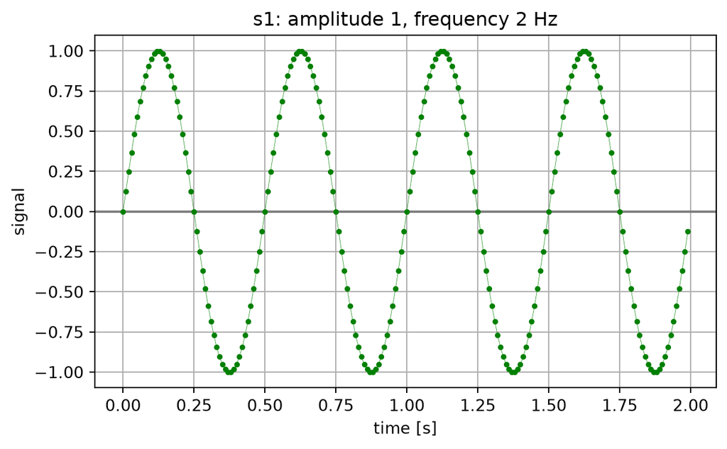

```python
# create a new figure of size 7 x 4 inches
plt.figure(figsize=(7, 4))

# draw s1 with my helper function (the x axis is time, not index)
plot_signal(t, s1, color="green", label="s1", xlabel="time [s]")

# add a title and a grid so the plot is easy to read
plt.title("s1: amplitude 1, frequency 2 Hz")
plt.grid(True)

# display the plot
plt.show()
```

It peaks at 1 and completes 4 cycles in 2 seconds, which matches the green curve in the figure.

### 3.1.7 Step 4: Second sine wave (s2)

From the figure, the orange wave:

- goes between -2 and 2, so amplitude = **2**
- repeats every 1 s, so frequency = **1 Hz**
- does not start at 0 but at about 1.7, and it peaks early (around 0.09 s). So it is shifted by a phase of about **1 radian**.

```python
# create s2 using the values we read from the figure
# amplitude = 2 (taller wave), frequency = 1 (slower wave),
# phase = 1.0 (shifts the wave so it starts at about 1.7 instead of 0)
s2 = sine_wave(t, amplitude=2, frequency=1, phase=1.0)
```

Let’s plot it.

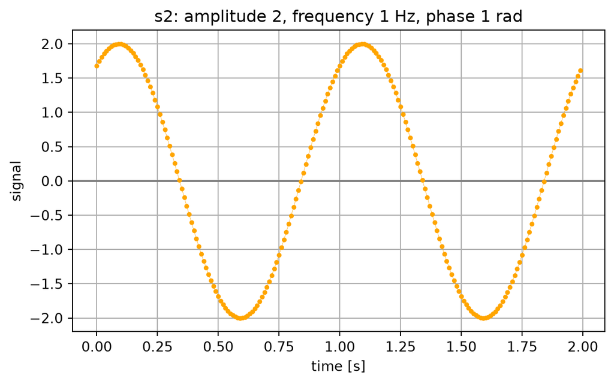

```python
# same plotting steps as for s1, only the data and color are different
plt.figure(figsize=(7, 4))
plot_signal(t, s2, color="orange", label="s2", xlabel="time [s]")

# title says which wave this is and what settings were used
plt.title("s2: amplitude 2, frequency 1 Hz, phase 1 rad")
plt.grid(True)
plt.show()
```

It starts at about 1.7, peaks at 2 and has 2 cycles in 2 seconds, like the orange curve in the figure.

### 3.1.8 Step 5: Combine them (s)

Now I just add the two waves point by point:

```python
# adding two numpy arrays adds them element by element,
# so at every time point: s = s1 + s2
s = s1 + s2
```

Plot the combined signal:

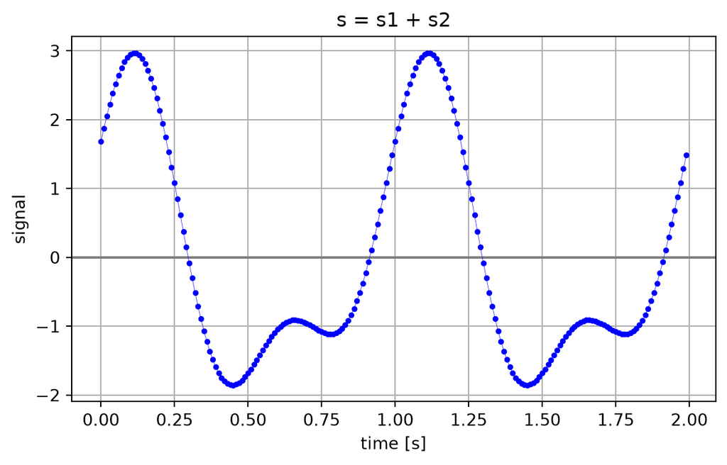

```python
# plot the combined signal in blue
plt.figure(figsize=(7, 4))
plot_signal(t, s, color="blue", label="s", xlabel="time [s]")
plt.title("s = s1 + s2")
plt.grid(True)
plt.show()
```

This looks more complicated than a single sine wave. The highs reach about 3 where both waves are high, and there are flatter dips around -1 where the waves partly cancel each other.

Let’s use `plot_remarkable_points` to mark the highest and the lowest value of `s`.

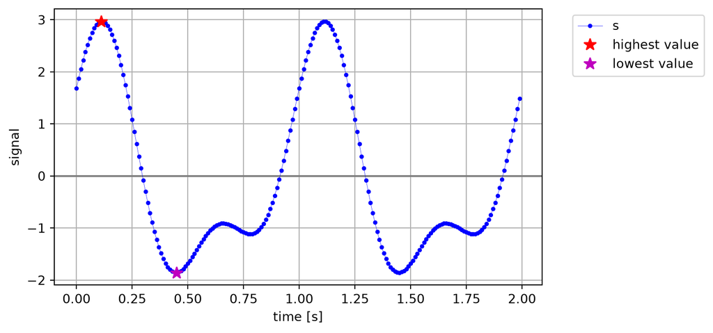

```python
# argmax / argmin give the position of the biggest / smallest value
i_highest = np.argmax(s)
i_lowest = np.argmin(s)

plt.figure(figsize=(7, 4))
plot_signal(t, s, color="blue", label="s", xlabel="time [s]")

# mark the two points with big stars
plot_remarkable_points(t[i_highest], s[i_highest], "*r", "highest value")
plot_remarkable_points(t[i_lowest], s[i_lowest], "*m", "lowest value")

plt.legend(bbox_to_anchor=(1.05, 1), loc="upper left")
plt.grid(True)
plt.show()
```

### 3.1.9 Putting it into one function

Now that each step works, I wrap the whole process in one function.

```python
def generate_signal(t):
    """Return s1, s2 and their sum s."""
    # first wave (green): small and fast
    s1 = sine_wave(t, amplitude=1, frequency=2, phase=0)

    # second wave (orange): bigger, slower and shifted
    s2 = sine_wave(t, amplitude=2, frequency=1, phase=1.0)

    # combined signal (blue): sum of the two waves
    s = s1 + s2

    # return all three so we can plot them later
    return s1, s2, s

# call the function; it gives back three arrays, one for each signal
s1, s2, s = generate_signal(t)
```

### 3.1.10 Final plot: all three signals together

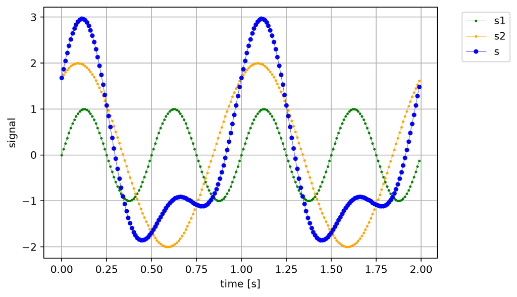

```python
# make one figure that will hold all three signals
plt.figure(figsize=(7, 4.5))

# draw each signal on the same plot
# label="..." is the name that will appear in the legend
# s1 and s2 use small dots, s uses bigger dots so it is easy to see
plt.plot(t, s1, color="green",  marker="o", markersize=1.5, linewidth=0.3, label="s1")
plt.plot(t, s2, color="orange", marker="o", markersize=1.5, linewidth=0.3, label="s2")
plt.plot(t, s,  color="blue",   marker="o", markersize=3.5, linewidth=0.3, label="s")

# axis labels and grid
plt.xlabel("time [s]")
plt.ylabel("signal")
plt.grid(True)

# show the legend outside the plot (top right) so it does not cover the curves
plt.legend(loc="upper left", bbox_to_anchor=(1.05, 1))

# display the final plot
plt.show()
```

## 3.2 Plot the remarkable points

### 3.2.1 Task

Once the signal is created, I find its remarkable points and plot them. I reuse the functions created by my team member in previous exercises instead of writing them again.

The remarkable points are:

- local maxima
- local minima
- positive zero crossings (the signal goes from negative to positive)
- negative zero crossings (the signal goes from positive to negative)

### 3.2.2 Reusing earlier functions

We will reuse the functions created in previous exercises by my team member.

I load only their Python code, so their text and plots do not appear in this document.

````python
def load_qmd_code(filename):
    """Run all the python code chunks of a .qmd file, without rendering the file."""
    # read the whole .qmd file as text
    text = Path(filename).read_text()

    # find every ```{python} ... ``` chunk and keep only the code inside
    chunks = re.findall(r"```\{python\}[^\n]*\n(.*?)```", text, flags=re.DOTALL)

    # run the chunks without displaying the plots from the source document
    original_show = plt.show
    plt.show = lambda *args, **kwargs: None
    try:
        with redirect_stdout(StringIO()):
            exec("\n\n".join(chunks), globals())
    finally:
        plt.show = original_show
        plt.close("all")

# the order matters: the maxima/minima file needs the zero-crossing functions
# Load earlier files from the sections folder
load_qmd_code("sections/02_1_zero_crossings.qmd")
load_qmd_code("sections/03_1_create_signal.qmd")
load_qmd_code("sections/02_3_local_maxima_minima.qmd")
````

The functions I reuse are:

- `make_time` and `generate_signal` to create the signal
- `plot_signal` and `plot_remarkable_points` to draw things
- `find_local_maxima_minima` to find the peaks and valleys
- `find_zero_crossings` and `plot_zero_crossings` for the zero crossings

### 3.2.3 Step 1: Create the signal

```python
# time axis from 0 to 2 seconds
t = make_time()

# s1 and s2 are the two sine waves, s is their sum
s1, s2, s = generate_signal(t)
```

Let’s plot `s` with `plot_signal`.

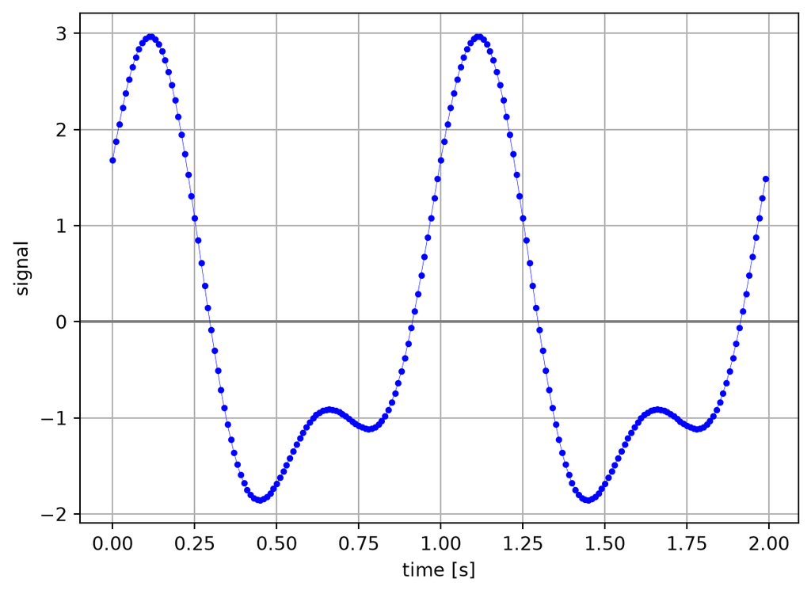

```python
plt.figure()

# draws the signal and a gray zero line
plot_signal(t, s)

# plot_signal writes "index" on the x axis, but our x axis is time
plt.xlabel("time [s]")

plt.grid(True)
plt.show()
```

This is the signal I want to analyse.

### 3.2.4 Step 2: Local maxima and minima

`find_local_maxima_minima` gives me the indices (positions) of the peaks and the valleys.

```python
# i_max = positions of local maxima, i_min = positions of local minima
i_max, i_min = find_local_maxima_minima(s)

# print the indices and the times they correspond to
print("Indices of local maxima:", i_max)
print("Times of local maxima  :", t[i_max])
print("Indices of local minima:", i_min)
print("Times of local minima  :", t[i_min])
```

```
Indices of local maxima: [ 11  66 111 166]
Times of local maxima  : [0.11 0.66 1.11 1.66]
Indices of local minima: [ 45  78 145 178]
Times of local minima  : [0.45 0.78 1.45 1.78]
```

Now let’s plot them on top of the signal.

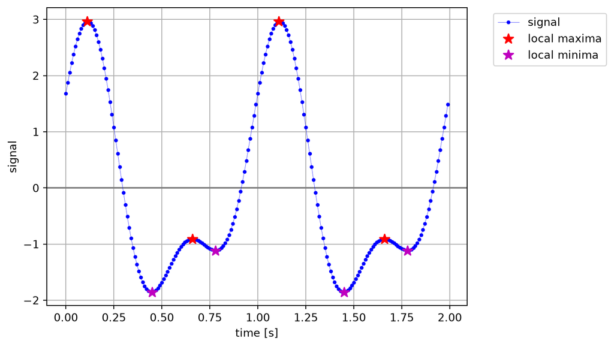

```python
plt.figure()
plot_signal(t, s)

# t[i_max] and s[i_max] are the time and value at each maximum
# I use star markers: red for maxima, magenta for minima
plot_remarkable_points(t[i_max], s[i_max], "*r", "local maxima")
plot_remarkable_points(t[i_min], s[i_min], "*m", "local minima")

plt.xlabel("time [s]")
plt.legend(bbox_to_anchor=(1.05, 1), loc="upper left")
plt.grid(True)
plt.show()
```

The stars sit on the tops of the peaks and the bottoms of the valleys, so the function works. The small bump around -1 gives one extra maximum and one extra minimum in each repetition of the signal.

### 3.2.5 Step 3: Zero crossings

`find_zero_crossings` gives the indices just before the signal changes sign.

```python
# i_pos = negative to positive, i_neg = positive to negative
i_pos, i_neg = find_zero_crossings(s)

print("Positive zero crossings at times:", t[i_pos])
print("Negative zero crossings at times:", t[i_neg])
```

```
Positive zero crossings at times: [0.91 1.91]
Negative zero crossings at times: [0.29 1.29]
```

Plot the zero crossings on the signal. `plot_zero_crossings` draws both kinds at once.

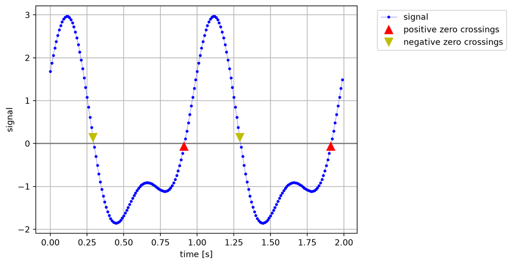

```python
plt.figure()
plot_signal(t, s)

# red triangle up = positive crossing, yellow triangle down = negative crossing
plot_zero_crossings(t, s)

plt.xlabel("time [s]")
plt.legend(bbox_to_anchor=(1.05, 1), loc="upper left")
plt.grid(True)
plt.show()
```

The triangles are placed where the signal passes through the gray zero line.

### 3.2.6 Step 4: All remarkable points together

To keep things clean, I put everything in one function that I can reuse for any signal.

```python
def display_remarkable_points(t, s):
    """Plot a signal with its local maxima/minima and zero crossings."""
    # find the local maxima and minima
    i_max, i_min = find_local_maxima_minima(s)

    plt.figure()

    # 1. the signal itself (drawn first, so the markers stay on top)
    plot_signal(t, s)

    # 2. local maxima and minima as stars
    plot_remarkable_points(t[i_max], s[i_max], "*r", "local maxima")
    plot_remarkable_points(t[i_min], s[i_min], "*m", "local minima")

    # 3. positive and negative zero crossings as triangles
    plot_zero_crossings(t, s)

    # labels, legend outside the plot, and grid
    plt.xlabel("time [s]")
    plt.legend(bbox_to_anchor=(1.05, 1), loc="upper left")
    plt.grid(True)
    plt.show()
```

### 3.2.7 Final result

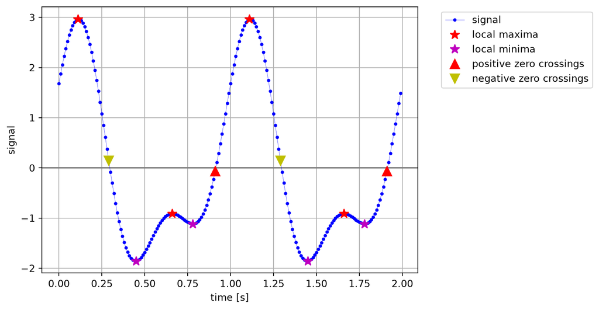

```python
display_remarkable_points(t, s)
```

## 3.3 Use the remarkable points to find the frequency of the signal

### 3.3.1 Task

Use the remarkable points to find the frequency of the signal. The idea is simple:

- find the zero crossing points that have the **same slope** (all the positive ones, or all the negative ones)
- the distance between two neighbouring ones is **one period** of the signal
- the frequency is one divided by the period

$$f = \frac{1}{T}$$

### 3.3.2 Reusing earlier functions

I load only the Python code of my earlier files, so their text and plots do not appear in this document.

The functions I reuse are:

- `make_time` and `generate_signal` to create the signal
- `find_zero_crossings` to find the zero crossing points
- `plot_signal` and `plot_remarkable_points` to draw things

### 3.3.3 Step 1: Create the signal

```python
# time axis from 0 to 2 seconds
t = make_time()

# s1 and s2 are the two sine waves, s is their sum
s1, s2, s = generate_signal(t)
```

### 3.3.4 Step 2: Zero crossings with the same slope

`find_zero_crossings` returns two arrays of indices:

- `i_pos`: crossings where the signal goes from negative to positive (positive slope)
- `i_neg`: crossings where the signal goes from positive to negative (negative slope)

```python
i_pos, i_neg = find_zero_crossings(s)

print("Indices of positive zero crossings:", i_pos)
print("Indices of negative zero crossings:", i_neg)
```

```
Indices of positive zero crossings: [ 91 191]
Indices of negative zero crossings: [ 29 129]
```

Let’s plot only the positive crossings first.

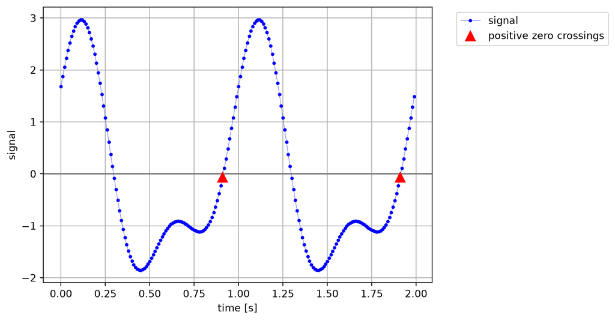

```python
plt.figure()
plot_signal(t, s)

# red triangles up: crossings with positive slope
plot_remarkable_points(t[i_pos], s[i_pos], "^r", "positive zero crossings")

plt.xlabel("time [s]")
plt.legend(bbox_to_anchor=(1.05, 1), loc="upper left")
plt.grid(True)
plt.show()
```

Now only the negative crossings.

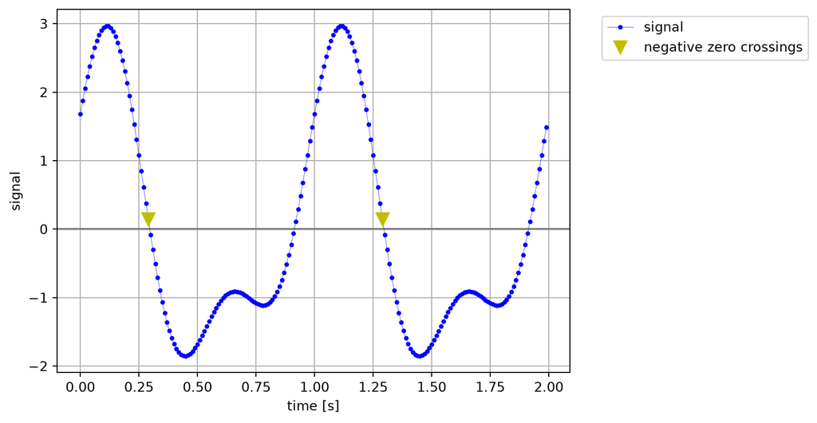

```python
plt.figure()
plot_signal(t, s)

# yellow triangles down: crossings with negative slope
plot_remarkable_points(t[i_neg], s[i_neg], "vy", "negative zero crossings")

plt.xlabel("time [s]")
plt.legend(bbox_to_anchor=(1.05, 1), loc="upper left")
plt.grid(True)
plt.show()
```

In both plots the points are spaced evenly. The distance between two neighbouring points of the same kind is one period of the signal.

### 3.3.5 Step 3: Distance between the crossings

First I measure the distance in **samples** (number of points between two crossings). `np.diff` gives the difference between neighbours.

```python
# distance in samples between neighbouring crossings of the same slope
delta_pos = np.diff(i_pos)
delta_neg = np.diff(i_neg)

print("delta_zero_crossing_pos (samples):", delta_pos)
print("delta_zero_crossing_neg (samples):", delta_neg)
```

```
delta_zero_crossing_pos (samples): [100]
delta_zero_crossing_neg (samples): [100]
```

There are 2 positive and 2 negative crossings, so there is one distance for each. Both are 100 samples.

### 3.3.6 Step 4: Period and frequency

To change samples into seconds I use the time vector. The time at each crossing is `t[i_pos]`, and the difference between neighbours is the period.

```python
# period in seconds: time between neighbouring crossings of the same slope
period_pos = np.mean(np.diff(t[i_pos]))
period_neg = np.mean(np.diff(t[i_neg]))

# the signal period is the average of the two estimates
period = (period_pos + period_neg) / 2

# frequency is 1 / period
frequency = 1 / period

print("Period from positive crossings:", round(period_pos, 6), "s")
print("Period from negative crossings:", round(period_neg, 6), "s")
print("Signal period                 :", round(period, 6), "s")
print("Signal frequency              :", round(frequency, 6), "Hz")
```

```
Period from positive crossings: 1.0 s
Period from negative crossings: 1.0 s
Signal period                 : 1.0 s
Signal frequency              : 1.0 Hz
```

### 3.3.7 Step 5: Put it all in one function

Now I put the steps together in one function. It takes the time vector and the signal and returns a dictionary with all the information.

```python
def compute_frequency_from_zero_crossings(t, s):
    """Estimate the period and frequency of a signal from its zero crossings.

    Parameters
    ----------
    t : np.ndarray
        Time vector.
    s : np.ndarray
        Signal vector.

    Returns
    -------
    dict
        Distances between crossings (in samples), periods (in seconds)
        and frequency (in Hz).
    """
    # 1. find the zero crossings with positive and negative slope
    i_pos, i_neg = find_zero_crossings(s)

    # 2. we need at least 2 crossings of the same kind to measure a distance
    if len(i_pos) < 2 or len(i_neg) < 2:
        raise ValueError("Not enough zero crossings to compute a period")

    # 3. distance between neighbouring crossings, in samples
    delta_pos = np.diff(i_pos)
    delta_neg = np.diff(i_neg)

    # 4. distance in seconds = period (average if there are several distances)
    period_pos = np.mean(np.diff(t[i_pos]))
    period_neg = np.mean(np.diff(t[i_neg]))

    # 5. final period is the average of the two, frequency is 1 / period
    period = (period_pos + period_neg) / 2
    frequency = 1 / period

    # 6. return everything in a dictionary
    return {
        "delta_zero_crossing_pos (samples)": delta_pos,
        "delta_zero_crossing_neg (samples)": delta_neg,
        "signal_period_pos (s)": period_pos,
        "signal_period_neg (s)": period_neg,
        "signal_period (s)": period,
        "signal_frequency (Hz)": frequency,
    }
```

A small function to print the dictionary in a clean way:

```python
def print_frequency_info(info):
    """Print the dictionary returned by compute_frequency_from_zero_crossings."""
    for key, value in info.items():
        # round the numbers so tiny float errors (1.0000000000000002) are hidden
        if isinstance(value, np.ndarray):
            text = str(value)
        else:
            text = str(round(float(value), 6))

        # right-align the names so the colons line up
        print(f"{key:>35} : {text}")
```

### 3.3.8 Final result

```python
info = compute_frequency_from_zero_crossings(t, s)
print_frequency_info(info)
```

```
  delta_zero_crossing_pos (samples) : [100]
  delta_zero_crossing_neg (samples) : [100]
              signal_period_pos (s) : 1.0
              signal_period_neg (s) : 1.0
                  signal_period (s) : 1.0
              signal_frequency (Hz) : 1.0
```

The result is a period of 1 s and a frequency of 1 Hz. This makes sense: `s` is the sum of `s1` (2 Hz) and `s2` (1 Hz). The pattern repeats every 1 s, which is the period of the slower wave.

### 3.3.9 Extra check with a simple signal

To be sure the function works in general, I test it on a single sine wave with a known frequency of 2 Hz. The period should be 0.5 s.

```python
# a sine wave of 2 Hz (phase 0.3 so it does not start exactly at zero)
s_test = sine_wave(t, amplitude=1, frequency=2, phase=0.3)

info_test = compute_frequency_from_zero_crossings(t, s_test)
print_frequency_info(info_test)
```

```
  delta_zero_crossing_pos (samples) : [50 50 50]
  delta_zero_crossing_neg (samples) : [50 50 50]
              signal_period_pos (s) : 0.5
              signal_period_neg (s) : 0.5
                  signal_period (s) : 0.5
              signal_frequency (Hz) : 2.0
```

The function finds a frequency of 2 Hz, so it works for other signals too.

# 4 4. Redo the analysis with a noisy signal

**Overview**: The aim is to investigate how adding noise affects the detection of remarkable points (zero crossings, local maxima, and minima), then use a low-pass filter to reduce that noise.

| Subsection | Task | Reused code |
| --- | --- | --- |
| 4.1 Create the noisy signal | Generate white noise, add it to the original signal, and plot it. | Original signal from Section 3.1 and `plot_signal()` from Section 2. |
| 4.2 Remarkable points | Detect zero crossings, local maxima, and minima, and analyze the effects of noise. | Detection and plotting functions from Section 2 and frequency calculation from Section 3.3. |
| 4.3 Low-pass filter | Apply a Butterworth filter and compare the filtered and noisy signals. | `butter`, `filtfilt`, and previous analysis functions. |

## 4.1 Create the noisy signal and plot it

**Objective:** To simulate measurement errors or disturbances, we add white noise to the original signal from Section 3. White noise introduces random fluctuations that can affect the detection of zero crossings, local maxima, and minima.

The noisy signal is obtained by adding random noise to the original signal:

$s_{noisy} = s_{original} + noise$

### 4.1.1 Define the noise level

We use `np.random.normal()` to generate white noise, where the random values follow a normal distribution.

First, we need to define how much the noise can fluctuate:

1. **Calculate the peak-to-peak amplitude:** Subtract the minimum value from the maximum value of the original signal.
2. **Set the noise level to 20%:** We use 20% of the peak-to-peak amplitude as the **standard deviation**, which controls how spread out the random noise values are around zero.

```python
# Calculate the peak-to-peak amplitude of the original signal
signal_amplitude = np.max(s) - np.min(s)

# Set the noise standard deviation to 20% of the amplitude
noise_std = 0.2 * signal_amplitude
```

### 4.1.2 Generate and add white noise

We use `np.random.normal()` to generate random noise values that follow a **normal distribution**. This means that values close to zero are more likely to occur, while large positive or negative values are less common.

We use a normal distribution because it can better simulate real measurement errors, such as sensor noise. Small fluctuations around zero are more common, while large fluctuations are less likely. This is useful for studying how noise affects the detection of remarkable points.

The function uses three parameters:

1. **Mean (`0`):** The noise values are centered around zero, so they can be positive or negative.
2. **Standard deviation (`noise_std`):** Controls how much the noise values vary. About 68% of the values fall within one standard deviation of zero, while larger fluctuations are less common.
3. **Number of samples (`len(s)`):** Generates one random noise value for each point of the original signal.

```python
# Generate one random noise value for each point of the original signal
noise = np.random.normal(0, noise_std, len(s))

# Add the random noise values to the original signal
s_noisy = s + noise

# Print the first 5 values to compare
print("Original signal:", s[:5])
print("Random noise:   ", noise[:5])
print("Noisy signal:   ", s_noisy[:5])
```

```
Original signal: [1.68294197 1.87280603 2.05379703 2.22374211 2.38055837]
Random noise:    [ 0.62450812 -0.17748862 -1.69137747 -2.33824024  1.99527074]
Noisy signal:    [ 2.30745009  1.6953174   0.36241955 -0.11449813  4.37582911]
```

### 4.1.3 Plot the noisy signal

**Graph interpretation**: The noise values are randomly scattered above and below zero, with no clear repeating pattern. This is expected because the noise values were generated independently using a normal distribution centered at zero.

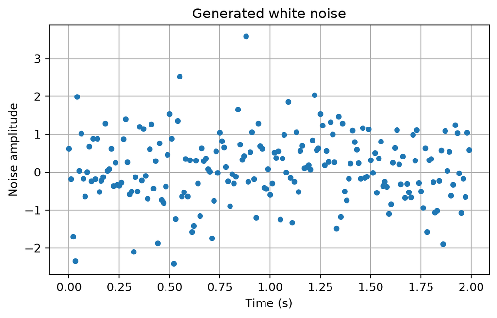

```python
# Create the figure
plt.figure(figsize=(7, 4))

# Plot the noise as blue dots without connecting lines
plt.plot(t, noise, "o", markersize=4)

# Add title, axis labels, and grid
plt.title("Generated white noise")
plt.xlabel("Time (s)")
plt.ylabel("Noise amplitude")
plt.grid(True)
plt.show()
```

Now we add a thin line (lw = 0.25) connecting the dots to better visualize the noisy signal

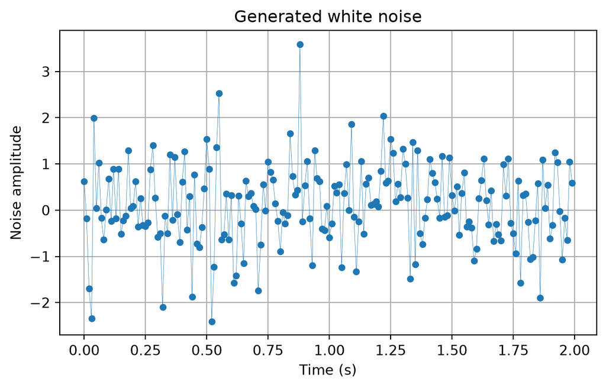

```python
# Create the figure
plt.figure(figsize=(7, 4))

# Plot the noise as blue dots connected by a thin line
plt.plot(t, noise, "o-", markersize=4, linewidth=0.25)

# Add title, axis labels, and grid
plt.title("Generated white noise")
plt.xlabel("Time (s)")
plt.ylabel("Noise amplitude")
plt.grid(True)
plt.show()
```

### 4.1.4 Compare the original and noisy signals

Now we plot the original signal (`s`) and the noisy signal (`s_noisy`) together to see how adding white noise changes the signal.

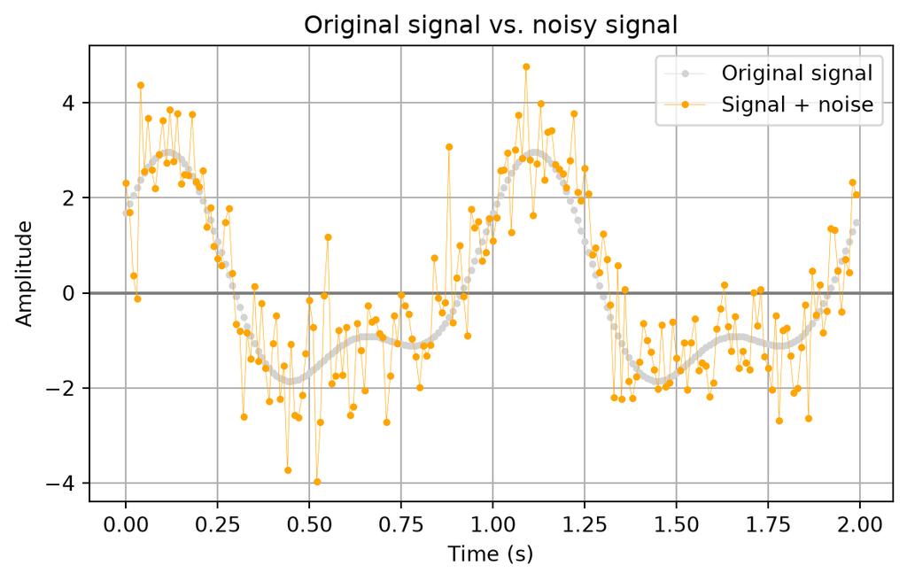

```python
# Create the figure
plt.figure(figsize=(7, 4))

# Plot the original signal in light gray
plot_signal(t, s, color="lightgray")
plt.gca().lines[-1].set_label("Original signal") # gets the current graph and accesses all lines and finds the last line [-1] cause the defined function plots one line at zero and the other is the original signal. Renames that line for the legend.

# Plot the noisy signal in orange
plot_signal(t, s_noisy, color="orange")
plt.gca().lines[-1].set_label("Signal + noise")

# Add title, labels, legend, and grid
plt.title("Original signal vs. noisy signal")
plt.xlabel("Time (s)")
plt.ylabel("Amplitude")
plt.legend()
plt.grid(True)
plt.show()
```

**Graph interpretation:** The noisy signal still follows the overall shape of the original signal but has additional random fluctuations. These fluctuations can create extra local maxima, minima, and zero crossings, making the detection of remarkable points more difficult.

## 4.2 Plot the remarkable points in the noisy signal

**Objective:** To investigate how adding white noise affects the detection of zero crossings, local maxima, and minima.

### 4.2.1 Identify remarkable points manually

Before using the detection functions from Section 2, we first examine the noisy signal to identify its remarkable points visually.

We first examine the noisy signal to identify local maxima, minima, and zero crossings by hand before using the detection functions. We use `%matplotlib widget` to zoom in on the signal and inspect individual points more closely.

A remarkable point is identified as follows:

| Point | How to identify it |
| --- | --- |
| Local maximum | A point higher than its neighboring points |
| Local minimum | A point lower than its neighboring points |
| Positive zero crossing | Signal changes from negative to positive |
| Negative zero crossing | Signal changes from positive to negative |

```python
# Enable interactive plotting to zoom in and inspect remarkable points
%matplotlib widget

#| out-width: "85%"
#| fig-align: center

plt.figure(figsize=(8, 5))
plot_signal(t, s_noisy)

plt.title("Noisy signal")
plt.xlabel("Time (s)")
plt.grid(True)
plt.show()
```

[output not shown]

### 4.2.2 Detect and plot the remarkable points

We now reuse the functions from Section 2 to automatically detect the local maxima, minima, and positive and negative zero crossings of the noisy signal.

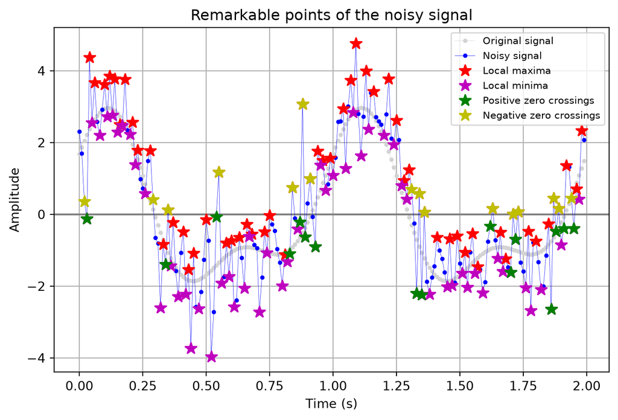

```python
# Find the local maxima and minima of the noisy signal
i_max, i_min = find_local_maxima_minima(s_noisy)

# Find the positive and negative zero crossings
i_pos, i_neg = find_zero_crossings(s_noisy)

# Plot the results

#| out-width: "85%"
#| fig-align: center

plt.figure(figsize=(8, 5))

# Plot the original signal in light gray
plot_signal(t, s, color="lightgray")
plt.gca().lines[-1].set_label("Original signal")

# Plot the noisy signal in blue
plot_signal(t, s_noisy, color="blue")
plt.gca().lines[-1].set_label("Noisy signal")

# Mark the detected remarkable points
plot_remarkable_points(t[i_max], s_noisy[i_max], "*r", "Local maxima")
plot_remarkable_points(t[i_min], s_noisy[i_min], "*m", "Local minima")
plot_remarkable_points(t[i_pos], s_noisy[i_pos], "*g", "Positive zero crossings")
plot_remarkable_points(t[i_neg], s_noisy[i_neg], "*y", "Negative zero crossings")

# Add title, labels, legend, and grid
plt.title("Remarkable points of the noisy signal")
plt.xlabel("Time (s)")
plt.ylabel("Amplitude")
plt.legend(loc="upper right", fontsize=8)
plt.grid(True)
plt.show()
```

**Graph interpretation**: The functions detect the local maxima, minima, and zero crossings in the noisy signal. However, the added noise creates many small fluctuations, resulting in extra peaks, valleys, and sometimes zero crossings that were not present in the original signal.

This happens because the functions detect changes between neighboring points without knowing whether they come from the original signal or from noise.

This is important because noise makes it harder to identify the meaningful remarkable points of the original signal, leading to extra detections and potentially inaccurate results. Therefore, filtering the noise may help improve the detection of these points.

### 4.2.3 Check the manually identified remarkable points against the detected ones

Compare these results with the points identified visually on the interactive graph. Note: the zero-crossing function returns the sample just before each sign change, rather than an interpolated crossing time.

```python
# Print the first 5 detected points of each type
print("Local maxima (s):", np.round(t[i_max][:5], 2))
print("Local minima (s):", np.round(t[i_min][:5], 2))
print("Positive zero crossings (s):", np.round(t[i_pos][:5], 2))
print("Negative zero crossings (s):", np.round(t[i_neg][:5], 2))
```

```
Local maxima (s): [0.04 0.06 0.1  0.12 0.14]
Local minima (s): [0.03 0.05 0.08 0.11 0.13]
Positive zero crossings (s): [0.03 0.34 0.54 0.83 0.87]
Negative zero crossings (s): [0.02 0.29 0.35 0.55 0.84]
```

## 4.3 Low pass filter the noisy signal

**Objective:** Reduce the random fluctuations in the noisy signal while keeping the overall shape of the original signal.

We use a **Butterworth low-pass filter**, which reduces high-frequency noise while allowing lower frequencies to pass through.

### 4.3.1 Create and apply the low-pass filter

We use a Butterworth low-pass filter to reduce the noise in our signal while keeping its original shape.

```python
# Calculate the sampling frequency
fs = 1 / (t[1] - t[0])

# Create a Butterworth low-pass filter
b, a = butter(4, 5, btype="low", fs=fs)

# Apply the filter to the noisy signal
s_filtered = filtfilt(b, a, s_noisy)

print("Sampling frequency:", round(fs, 2), "Hz")
print("Filter coefficients (b):", b)
print("Filter coefficients (a):", a)
print("Filtered signal (first 5 samples):", s_filtered[:5])
```

```
Sampling frequency: 100.0 Hz
Filter coefficients (b): [0.0004166 0.0016664 0.0024996 0.0016664 0.0004166]
Filter coefficients (a): [ 1.         -3.18063855  3.86119435 -2.11215536  0.43826514]
Filtered signal (first 5 samples): [2.2836083  2.33667624 2.39273406 2.45436319 2.52304523]
```

1. How does the filter work?

Our original signal contains two frequencies: 1 Hz and 2 Hz. However, adding white noise introduces random fluctuations across many frequencies, including high frequencies that cause the signal to look irregular.

A low-pass filter reduces the higher frequencies while allowing lower frequencies to pass through.

We chose a cutoff frequency of 5 Hz because it is higher than both original frequencies (1 Hz and 2 Hz). This allows us to keep most of the original signal while reducing higher-frequency noise. Frequencies above 5 Hz are progressively reduced rather than completely removed.

2. Why use a Butterworth filter instead of a moving average?

A moving average reduces fluctuations by replacing each point with the average of a group of neighboring points. The number of points used to calculate this average is called the window size. For example, a window size of 10 means that 10 points are averaged to calculate each new value. Although this makes the signal smoother, it can also change the shape and amplitude of peaks, especially if the window size is too large.

A Butterworth filter works differently: it reduces unwanted frequencies based on a chosen cutoff. Since we already know our original signal contains 1 Hz and 2 Hz components, we can choose a cutoff of 5 Hz to preserve them. Thus, the Butterworth filter reduces noise without significantly changing the shape of the original signal.

3. Creating the filter with butter()

We used butter(4, 5, btype=“low”, fs=fs) with the following parameters:

- Filter order (4): Controls how quickly higher frequencies are reduced. A higher order produces a sharper reduction above the cutoff. We choose order 4 to reduce noise without making the filter unnecessarily sharp.
- Cutoff frequency (5): Frequencies below 5 Hz are mostly preserved, while higher frequencies are progressively reduced.
- Filter type (btype=“low”): Specifies that we want a low-pass filter.
- Sampling frequency (fs=fs): Tells the filter how many signal points were sampled per second. Our signal contains one point every 0.01 seconds, giving a sampling frequency of 100 Hz.
- The butter() function then calculates two sets of coefficients, b and a, which define how the filter processes the signal. These coefficients are calculated automatically by SciPy.
4. Applying the filter with filtfilt()

Once the filter is created, we apply it to the noisy signal using filtfilt(b, a, s_noisy).

Normally, filtering in only one direction can introduce a phase shift, meaning peaks and zero crossings may appear slightly later than in the original signal.

To avoid this, filtfilt() applies the filter twice:

- Forward: From the beginning to the end of the signal.
- Backward: From the end to the beginning.

Filtering in both directions cancels the phase shift and provides additional noise reduction.

5. Why is this important?

Our assignment focuses on detecting remarkable points, such as local maxima, minima, and zero crossings. We want to reduce noise without introducing artificial delays that would change when these points occur.

Using filtfilt() helps preserve their timing, making it easier to compare the original, noisy, and filtered signals. However, filtering can still change peak amplitudes and shapes, and some noise may remain.

### 4.3.2 Plot and compare the filtered signal

We plot the original, noisy, and filtered signals together to see how effectively the Butterworth filter reduces the noise while preserving the original shape of the signal.

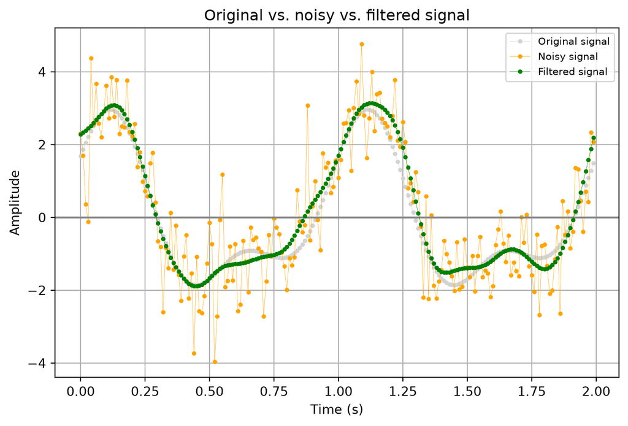

```python
# Create the figure
plt.figure(figsize=(8, 5))

# Plot the original signal in light gray
plot_signal(t, s, color="lightgray")
plt.gca().lines[-1].set_label("Original signal")

# Plot the noisy signal in orange
plot_signal(t, s_noisy, color="orange")
plt.gca().lines[-1].set_label("Noisy signal")

# Plot the filtered signal in green
plot_signal(t, s_filtered, color="green")
plt.gca().lines[-1].set_label("Filtered signal")

# Add title, labels, legend, and grid
plt.title("Original vs. noisy vs. filtered signal")
plt.xlabel("Time (s)")
plt.ylabel("Amplitude")
plt.legend(loc="upper right", fontsize=8)
plt.grid(True)
plt.show()
```

**Graph interpretation**: After applying the Butterworth low-pass filter, the signal becomes smoother and closely follows the original signal. Most of the rapid fluctuations caused by white noise are reduced, while the main peaks, valleys, and overall shape are preserved. However, the filtered signal does not perfectly match the original because some noise remains.

By reducing the small fluctuations, it improves the detection of remarkable points by removing many additional local maxima, minima, and zero crossings caused by noise.

### 4.3.3 Detect remarkable points in the filtered signal

We now use the functions from Section 2 to detect local maxima, minima, and zero crossings in the filtered signal.

The aim is to check whether removing noise reduces the additional remarkable points detected in the noisy signal.

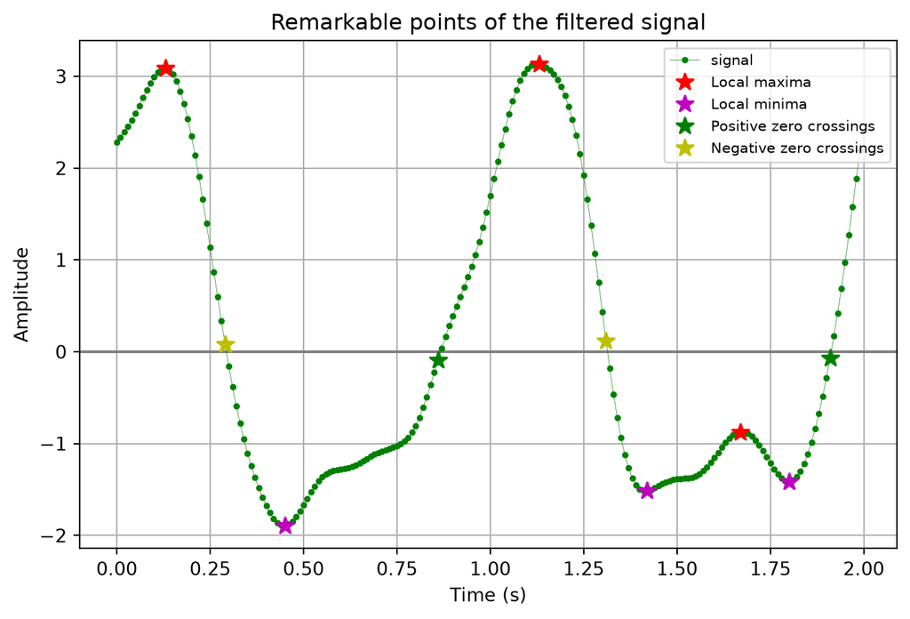

```python
# Detect maxima and minima in the filtered signal
i_max_f, i_min_f = find_local_maxima_minima(s_filtered)

# Detect positive and negative zero crossings
i_pos_f, i_neg_f = find_zero_crossings(s_filtered)

# Create the figure

#| out-width: "85%"
#| fig-align: center

plt.figure(figsize=(8, 5))

# Plot the filtered signal
plot_signal(t, s_filtered, color="green")

# Mark the detected remarkable points
plot_remarkable_points(t[i_max_f], s_filtered[i_max_f], "*r", "Local maxima")
plot_remarkable_points(t[i_min_f], s_filtered[i_min_f], "*m", "Local minima")
plot_remarkable_points(t[i_pos_f], s_filtered[i_pos_f], "*g", "Positive zero crossings")
plot_remarkable_points(t[i_neg_f], s_filtered[i_neg_f], "*y", "Negative zero crossings")

# Add title, labels, legend, and grid
plt.title("Remarkable points of the filtered signal")
plt.xlabel("Time (s)")
plt.ylabel("Amplitude")
plt.legend(loc="upper right", fontsize=8)
plt.grid(True)
plt.show()
```

**Graph interpretation**: After filtering, the signal is much smoother, with fewer local maxima and minima compared to the noisy signal. Most of the additional peaks and valleys caused by noise have disappeared, while the main remarkable points are preserved.

Detection functions can now identify the meaningful peaks, valleys, and zero crossings more easily, with fewer unwanted detections caused by noise.

### 4.3.4 Compare the signal frequencies

We reuse the frequency calculation function from Section 3.3 to check whether filtering improves the frequency estimate.

```python
# Calculate frequency for each signal
info_original = compute_frequency_from_zero_crossings(t, s)
info_noisy = compute_frequency_from_zero_crossings(t, s_noisy)
info_filtered = compute_frequency_from_zero_crossings(t, s_filtered)

# Print the calculated frequencies
print("Original signal:")
print_frequency_info(info_original)

print("\nNoisy signal:")
print_frequency_info(info_noisy)

print("\nFiltered signal:")
print_frequency_info(info_filtered)
```

```
Original signal:
  delta_zero_crossing_pos (samples) : [100]
  delta_zero_crossing_neg (samples) : [100]
              signal_period_pos (s) : 1.0
              signal_period_neg (s) : 1.0
                  signal_period (s) : 1.0
              signal_frequency (Hz) : 1.0

Noisy signal:
  delta_zero_crossing_pos (samples) : [31 20 29  4  2  4 40  2 27  8  2 14  2  3  4]
  delta_zero_crossing_neg (samples) : [27  6 20 29  4  3 40  3  2 27  8  2 14  2  5]
              signal_period_pos (s) : 0.128
              signal_period_neg (s) : 0.128
                  signal_period (s) : 0.128
              signal_frequency (Hz) : 7.8125

Filtered signal:
  delta_zero_crossing_pos (samples) : [105]
  delta_zero_crossing_neg (samples) : [102]
              signal_period_pos (s) : 1.05
              signal_period_neg (s) : 1.02
                  signal_period (s) : 1.035
              signal_frequency (Hz) : 0.966184
```

# 5 5. Critical points and problem solving

## 5.1 Critical point 1: Managing generated HTML files

### 5.1.1 Problem encountered

Each group member worked on a separate .qmd file and needed to render it as HTML to check the code, explanations, and graphs without rendering the entire main document every time.

However, rendering individual sections generated additional HTML files and folders that appeared as changes in GitHub Desktop. We did not want to manually exclude these files every time we made a commit because they were only generated for preview purposes.

### 5.1.2 Solution implemented

We updated the .gitignore file to automatically ignore the generated HTML files and temporary Quarto folders.

This allowed each member to preview their work independently without adding unnecessary generated files to the Git repository, keeping commits cleaner and easier to manage.

## 5.2 Critical point 2: Reusing functions and libraries across sections

### 5.2.1 Problem encountered

Our assignment was divided into separate .qmd files, but later sections needed to reuse functions and variables from earlier sections. Although the files were included in the correct order in the main Quarto document, we encountered errors when trying to reuse this code.

For example, Section 4 needed the original signal (s) and time vector (t) from Section 3, but these variables were not available because the latest Section 3 changes had not yet been merged into our working branch.

After updating the branch, we also encountered a FileNotFoundError because the load_qmd_code() function was looking for earlier .qmd files in the wrong directory.

### 5.2.2 Solution implemented

We updated our working branch with the latest completed sections from main so that the required functions and variables were available.

We then corrected the file paths in load_qmd_code() by adding sections/ before the filenames, allowing Python to locate and execute the earlier files.

We also added shared library imports to the main Quarto document so they were available throughout the assignment.

These changes allowed us to reuse our teammates’ functions instead of rewriting them and ensured that the sections worked together when rendering the full document.

## 5.3 Critical point 3

### 5.3.1 Problem encountered

While organizing our GitHub repository, we renamed the branch for Section 1. However, this caused the original pull request to close automatically, even though the section was not yet merged into main.

This created confusion because the completed work was still available, but the original pull request could no longer be used to review and merge it.

### 5.3.2 Solution implemented

We created a new pull request using the correct branch and checked that it contained the intended changes before merging.

This showed us the importance of keeping branch names consistent and avoiding unnecessary branch renaming while pull requests are open, especially when several group members are contributing to the same repository.